# Approximating Geometric Distributions with the exponential distribution

Eric C. Anderson

```r
library(tidyverse)
```

Here is some code that you can use to explore how similar the exponential distribution is to the geometric distribution. Recall that it is easy to show in a Wright Fisher population of $N$ diploids (i.e., with $2N$ gene copies), that the probability that a pair of genes have a common ancestor $t$ generations in the past is
$$\biggl(1 - \frac{1}{2N}\biggr)^{t-1} \frac{1}{2N}$$
Let’s make a function that computes that for $N$ and different values of $t$:

```r
G <- function(N, t) {
  (1 - (1 / (2 * N)))^(t - 1) * (1 / (2 * N) )
}
```

Then let’s look at those values for, say $t=1,\ldots,50$ when $N=30$:

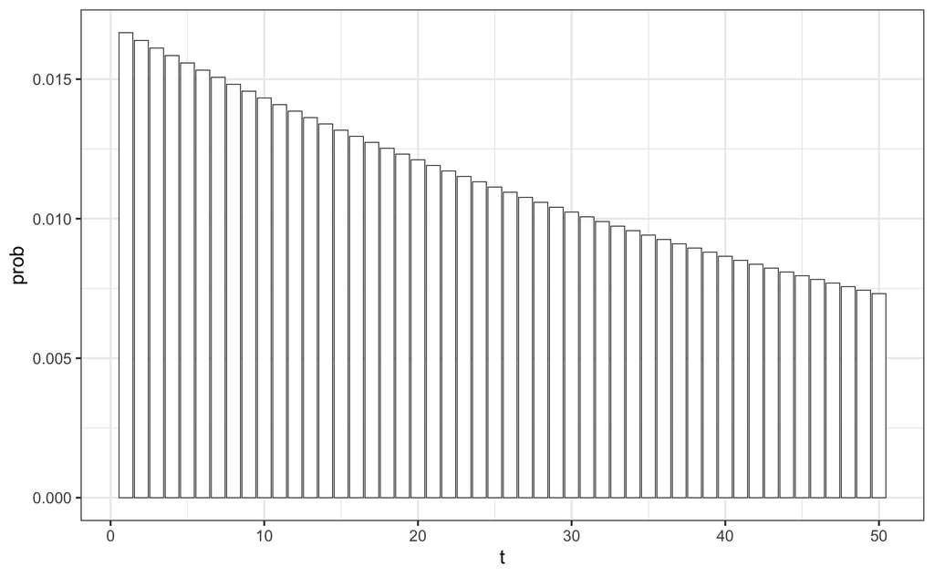

```r
geomet <- tibble(
  t = 1:50,
  prob = G(30, 1:50)
)

ggplot(geomet, aes(x = t, y = prob)) +
  geom_col(colour = "black", fill = "white", linewidth = 0.2) +
  theme_bw()
```

That defines the geometric distribution, which takes discrete values on $1,2,\ldots$.

Now, remember how we said that a reasonable approximation to those values can be found with the exponential distribution, which also allows for real numbers. Here is a function that defines the approximating exponential distribution:
$$\frac{1}{2N} e^{-\frac{t}{2N}}$$

```r
E <- function(N, t) {
  (1 / (2 * N)) * exp(-t / (2 * N))
}
```

And here we plot it in blue on top of the geometric distribution for $N=30$:

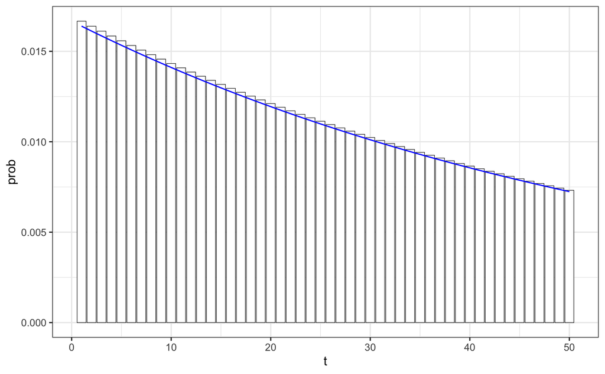

```r
expy <- tibble(
  t = 1:50,
  density = E(30, 1:50)
)

ggplot() +
  geom_col(data = geomet, aes(x = t, y = prob),
           colour = "black", fill = "white", linewidth = 0.2) +
  geom_line(data = expy, aes(x = t, y = density), colour = "blue") +
  theme_bw()
```

That is pretty darn close, even for an $N$ as small as 30. And the approximation gets better as $N$ gets larger….